# Natural Language Processing Exploratory Data Analysis

Abiyu Giday

March 19, 2016

## Motivation:

This report is prepared to show the steps taken to download and import unstructured collection of text data into a local dataset and use various text mining software packages to perform exploratory data analysis. The report will include statistical summaries, plots and share interesting insights found in the data. The data sets used here are in English language. The text data is randomly scraped from the web and includes news snippets, blog texts and twitter messages.

Natural Language Processing (NLP) is a field of study that focuses on “computers to process and understand human languages.” As such, the text mining process follows specific set of steps in order to get the data in a structured format to get it ready for further statistical analysis and developing data mining applications.”

## Examing the data and its content

This is a reproducible document that starts with downloading the data from the source, import the data to R memory, sample the data, import all data into corpus, tidy/cleanup the corpus, generate three ngram models (unigram, bigram, trigram) using text mining packages, explore the data by looking at frequency distribution of words, visualize the data with wordcloud, ggplot and drawing conclusion of what is observed.

### Import the data

The first step is to import the data. A combination of R and UNIX command lines(sampling) are used to import the data into R and create a “Corpus”. A corpora is a container framework of several different data from various sources, similar to an SQL database that holds several tables. Except that the data in Corpa is often unstructured, meaning does not’t necessarily fit neatly into rectangular data frame, as required by structured databases. No specific definition of variables, rows and columns. On our case we are going to dump the news snippets, the blog text and twitter messages into a software container - Corpa. This provides a common interface to all the documents that reside int he Corpa, making it efficient to work with thousands even millions of documents at once.

### Packages used for the exploratory data

```r
setwd("~/Documents/Data-Science/DataScienceSpecialization/Capstone") #set working direcotry

library(tm)                     # Text Mining Package Version: 0.6-2
library(RWeka)                  # An R interface to Weka (Version 3.7.13) - RWeka version 0.4-2
library(stringi)                # String Processing Package Version: stringi_1.0-1
library(stringr)                # String manipulation Package Version:  stringr_1.0.0
library(wordcloud)              # Word Clouds Version: 2.5
library(ggplot2)                # Grammar of graphics in R Version: 2.1.0
library(dplyr)                     # DataTables library in R Version: 0.1
options(mc.cores=1)             # Change the default core processor to use - for RWeka set to 1
# rm(list = ls())
```

download and unzip the data

```r
if(!file.exists("./data")){dir.create("./data")}
fileUrl <- "https://d396qusza40orc.cloudfront.net/dsscapstone/dataset/Coursera-SwiftKey.zip"
download.file(fileUrl, destfile = "./data/Coursera-SwiftKey.zip", method = "curl")

unzip("./data/Coursera-SwiftKey.zip")  #unizp the file;  #creates a directory named final
dir("final") #confirm data is downloaded
```

### The statstics of the data

### Sample the data

```r
#read the raw text files
setwd("~/Documents/Data-Science/DataScienceSpecialization/Capstone")
 news  <- scan(file = './final/en_US/en_US.news.txt'   ,    sep = '\n', what = '', skipNul = TRUE)
 blog  <- scan(file = './final/en_US/en_US.blogs.txt'  ,    sep = '\n', what = '', skipNul = TRUE)
 tweet <- scan(file = './final/en_US/en_US.twitter.txt',    sep = '\n', what = '', skipNul = TRUE)

 news.data <-sample(news,length(blog)   *.01, replace=FALSE)       # Sample 2% of the news data without replacment
 blog.data <-sample(blog,length(blog)   *.01, replace=FALSE)       # Sample 2% of the blog data without replacment
 tweet.data <-sample(tweet,length(blog) *.01, replace=FALSE)       # Sample 2% of the blog data without replacment
```

Examine the data number of bytes, character and total number of words for the entire raw data. We are starting with 102.4 million words.

```r
 library(stringi)
 library(stringr)
# -c      The number of bytes
# -l      The number of lines
# -m      The number of characters
# -w      The number of words
# system("wc -clmw final/en_US/en_US.*.txt")
stri_stats_general(blog)                                      # Blog stats
```

```
##       Lines LinesNEmpty       Chars CharsNWhite
##      899288      899288   206824382   170389539
```

```r
stri_stats_general(news)                                      # News stats
```

```
##       Lines LinesNEmpty       Chars CharsNWhite
##     1010242     1010242   203223154   169860866
```

```r
stri_stats_general(tweet)                                     # Tweet stats
```

```
##       Lines LinesNEmpty       Chars CharsNWhite
##     2360148     2360148   162096241   134082806
```

```r
stri_stats_general(c(blog, news, tweet))                      # Combined Sats for the raw text
```

```
##       Lines LinesNEmpty       Chars CharsNWhite
##     4269678     4269678   572143777   474333211
```

```r
Total_word_count   <- stri_count_words(c(blog, news, tweet))  # Word count
sum(Total_word_count)                                         # 102,402,051 there are 102.4 millon words
```

```
## [1] 102402051
```

```r
#summary(Total_word_count)
rm(news, blog, tweet)                                              # Remove raw files
```

Statistics of the sampled data shows that we have seven hundred ninety thousand combined words.

```r
 stri_stats_general(c(blog.data, news.data, tweet.data))
```

```
##       Lines LinesNEmpty       Chars CharsNWhite
##       26976       26976     4479626     3714113
```

```r
 Total_word_count   <- stri_count_words(c(blog.data, news.data, tweet.data))
 sum(Total_word_count)
```

```
## [1] 796943
```

### Spliting sentence boundries

Before importing the three files into a corpus we **split lines into sentences.** For that we are going to use a regex expression that will identify sentences that end with a “.”, “!” and “?”. IT is supposed to not treat the period in “St. Louis” or “Lyndon B. Johnson”" as end of sentence.

```r
news.data1  <- stri_split_regex(c(news.data) ,"( [A-Z]\\. )(?<!\\w\\.\\w.)(?<![A-Z][a-z]\\.)(?<=\\.|\\?|\\!)\\s") # added reg ex
blog.data1  <- stri_split_regex(c(blog.data) , "( [A-Z]\\. )(?<!\\w\\.\\w.)(?<![A-Z][a-z]\\.)(?<=\\.|\\?|\\!)\\s")
tweet.data1 <- stri_split_regex(c(tweet.data), "( [A-Z]\\. )(?<!\\w\\.\\w.)(?<![A-Z][a-z]\\.)(?<=\\.|\\?|\\!)\\s")
```

### Generate Corpus

Load the data and create the Corpus with the following steps:

```r
data.Corpus <- VCorpus(VectorSource(c(blog.data1, news.data1, tweet.data1))) #corpus
#[ reached getOption("max.print") -- omitted 16976 entries ]
```

Display detailed information on a corpus with the following commands.

```r
inspect(data.Corpus)
summary(data.Corpus)
```

We can view the content inside the Corpa as follows. As an example:

```r
head(as.character(data.Corpus[[3]]))
```

## Preprocess and cleaning the Corpus

Now that we have our collection of text neatly seating in the Corpa, we will need to do preliminary cleaning up of the data (or tidy the data). This includes removing profane words, white spaces, numbers and computations. When cleaning the corpous, it is important to follow specific set of steps in order avoid loosing certain key words.

### A fucntion that will clean the data

The first function removes none English letters and punctuations including ones used to create emoji on tweets. We also import list profane words saved in a file so they can be used to match and remove profane words. We then create function that contains the tm_map function to remove the content.

```r
setwd("~/Documents/Data-Science/DataScienceSpecialization/Capstone")

rmvNonEngGsub <- function(x) { gsub(pattern="[^[:alpha:]]", " ", x) }  # remove letters that are not A-Z or numbers 0 -9

con1 <- file("./final/profanewords.txt", "r")                         # import collecton of profane words saved as txt
profanewords <- readLines(con1)
close(con1)

preProcessFunction <- function(myCorpus) {                            # main function that will clean the corupus
        myCorpus <- tm_map(myCorpus, rmvNonEngGsub)
        myCorpus <- tm_map(myCorpus, content_transformer(tolower))
        myCorpus <- tm_map(myCorpus, removeWords, stopwords("english"))
        myCorpus <- tm_map(myCorpus, removePunctuation)
        myCorpus <- tm_map(myCorpus, removeWords, profanewords)
        myCorpus <- tm_map(myCorpus, removeNumbers)
        myCorpus <- tm_map(myCorpus, stemDocument)
        myCorpus <- tm_map(myCorpus, removeWords, c(" u ", "^aa ", "la la la "))
        myCorpus <- tm_map(myCorpus, stripWhitespace)
        myCorpus <- tm_map(myCorpus, PlainTextDocument)
        return (myCorpus)
                                         }
#as.character(twtdb_clean[[1]])
#inspect(twtdb_clean)
```

Next is to clean the data using the functions created.

```r
system.time(data.corpus_clean <- preProcessFunction(data.Corpus)) #clean the data
```

```
##    user  system elapsed
##   6.564   0.024   6.586
```

```r
# the following commands can be used to examine the corpus. For brevity, it is commented out.
#inspect(data.corpus_clean)
#summary(data.corpus_clean)
#as.character(data.corpus_clean[[2002]])
```

## Tokenize the data (ngram)

We start tokenizing the data with the following commands to see the distribution of word frequency in the corpus. We can also see the sparsity (ho much of the data are zero) percentile and maximum term length in the dataset.

### Unigram - one word token

```r
unigramTDM   <- TermDocumentMatrix(data.corpus_clean)
#inspect(unigramTDM)
 #<<TermDocumentMatrix (terms: 49103, documents: 26976)>>
#Non-/sparse entries: 386812/1324215716
#Sparsity           : 100%
#Maximal term length: 74
#Weighting          : term frequency (tf)

#summary(unigramTDM)
#unigramTDM  <- removeSparseTerms(unigramTDM , 0.95) #reduce sparsity
m <- as.matrix(unigramTDM)
v <- sort(rowSums(m),decreasing=TRUE)
df_unigram <- data.frame(words = names(v),freq=v)
row.names(df_unigram) <- NULL
head(df_unigram, 10)
```

```
##    words freq
## 1   said  516
## 2    one  479
## 3   will  459
## 4   just  418
## 5   like  389
## 6    can  354
## 7   time  312
## 8    get  310
## 9    new  301
## 10  good  243
```

```r
#tail(df_unigram, 10)
#View(df_unigram)
```

### Bigram - two words token

```r
options(mc.cores=1)
biagramTokenizer <- function(x) {RWeka::NGramTokenizer(x, RWeka::Weka_control(min = 2, max = 2))} #biagram function

biagramTDM   <- TermDocumentMatrix(data.corpus_clean, control=list(tokenize = biagramTokenizer))
biagramTDM  #TermDocumentMatrix (terms: 37634, documents: 2697)
```

[output not shown]

```r
#inspect(biagramTDM)
#biagramTDM <- removeSparseTerms(biagramTDM, 0.99) #reduce sparsity
#head(inspect(biagramTDM),20)

#inspect(biagramTDM)
#as.character(biagramTDM[[1]])
m <- as.matrix(biagramTDM)                              #convert to mamtrix
v <- sort(rowSums(m),decreasing=TRUE)                   #sort high to low
df_biagram <- data.frame(words = names(v),freq=v)       #convert to dataframe
row.names(df_biagram) <- NULL                           #remove row lable
head(df_biagram, 10)
```

```
##         words freq
## 1    new york   32
## 2   last year   31
## 3   right now   29
## 4   feel like   27
## 5   last week   24
## 6  first time   17
## 7  last night   17
## 8   just like   16
## 9   make sure   16
## 10 new jersey   16
```

```r
#tail(df_biagram, 10)
#View(df_biagram)
```

Trigram

```r
triagramTokenizer <- function(x) {RWeka::NGramTokenizer(x, RWeka::Weka_control(min = 3, max = 3))} #triagram function

triagramTDM   <- TermDocumentMatrix(data.corpus_clean, control=list(tokenize = triagramTokenizer))
triagramTDM
```

[output not shown]

```r
#triagramTDM  <- removeSparseTerms(triagramTDM, 0.80) #reduce sparsity
#head(inspect(triagramTDM),10)

m <- as.matrix(triagramTDM)                             #convert to matrix
v <- sort(rowSums(m),decreasing=TRUE)                   #sort high to low
df_triagram <- data.frame(words = names(v),freq=v)      #convert to dataframe
row.names(df_triagram) <- NULL                          #remove row lable
head(df_triagram, 10)
```

```
##                   words freq
## 1               bmw z i    3
## 2  city council members    3
## 3     green bay packers    3
## 4     happy mothers day    3
## 5              la la la    3
## 6         long time ago    3
## 7    martin luther king    3
## 8         new york city    3
## 9        next next next    3
## 10      one main things    3
```

```r
#tail(df_triagram,10)
#View(df_triagram)
###########
```

### histograms of tokens

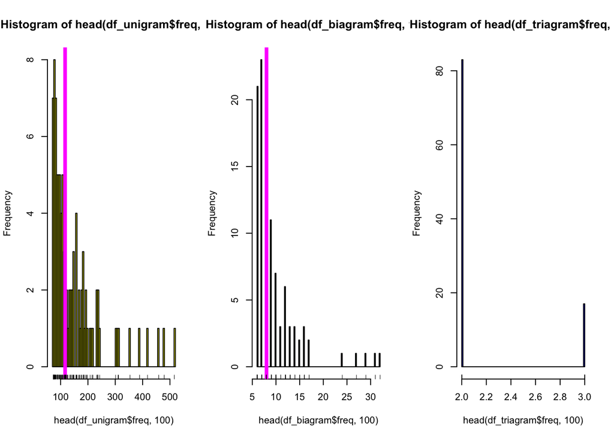

### Relative Term Frequency of the tokens for unigram

```
## [1]   1 516
```

```
##    token.counts  Freq    rltvFreq
## 1         [1,5) 16155 0.831446217
## 2         [5,9)  1521 0.078281009
## 3        [9,13)   572 0.029439012
## 4       [13,17)   322 0.016572311
## 5       [17,21)   186 0.009572826
## 6       [21,25)   139 0.007153886
## 7       [25,29)    97 0.004992280
## 8       [29,33)    81 0.004168811
## 9       [33,37)    54 0.002779207
## 10      [37,41)    42 0.002161606
```

Here are some of the exploratory statistics for mean, median, variance and standard deviation for the sampled data.

```r
mean(df_unigram$freq)                               # measure of center distribution
```

```
## [1] 4.280261
```

```r
median(df_unigram$freq)                             # median is a better representation of center
```

```
## [1] 1
```

```r
var(df_unigram$freq)                                # variance
```

```
## [1] 197.6429
```

```r
sd(df_unigram$freq)
```

```
## [1] 14.05855
```

## Wordcloud Visualization for the most frequently words unigram, bigram, trigram

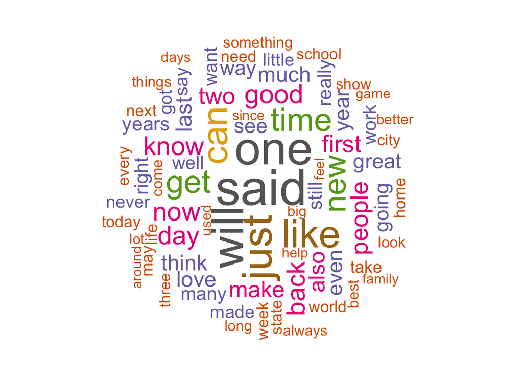

```r
mfrow = c(1,3)

library(wordcloud)

wordcloud(words = df_unigram$word, freq = df_unigram$freq, min.freq = 3,
          max.words=75, random.order=FALSE, rot.per=0.35,
          colors=brewer.pal(8, "Dark2"))
```

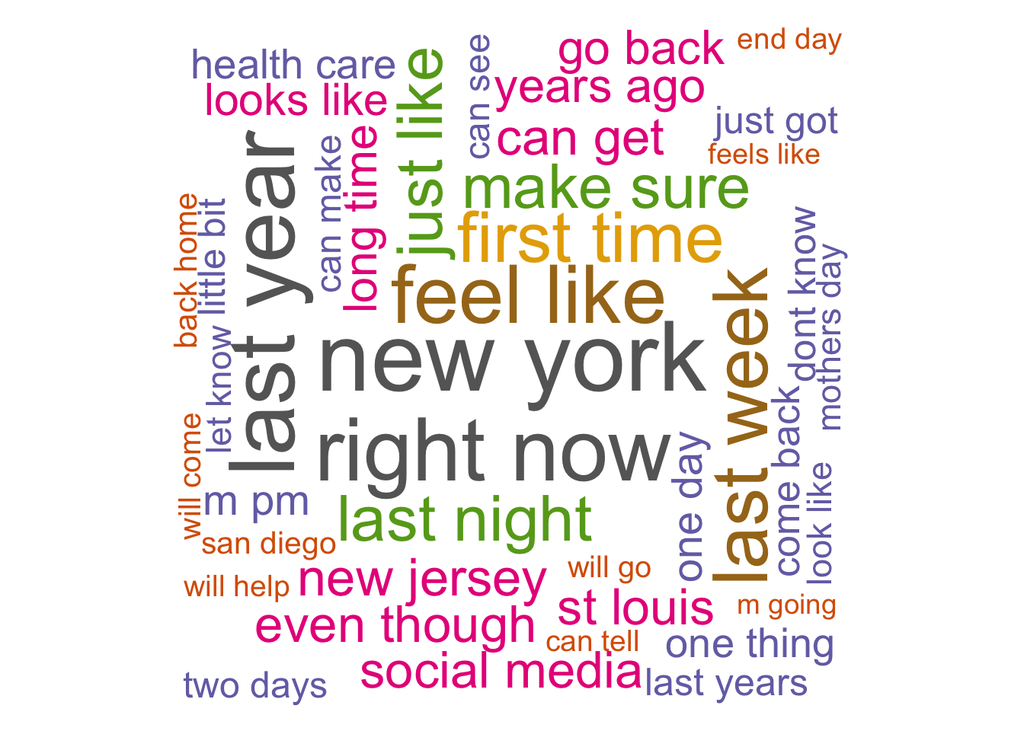

```r
wordcloud(words = df_biagram$word, freq = df_unigram$freq, min.freq = 3,
          max.words=75, random.order=FALSE, rot.per=0.35,
          colors=brewer.pal(8, "Dark2"))
```

[figure not shown]

```r
wordcloud(words = df_triagram$word, freq = df_unigram$freq, min.freq = 3,
          max.words=75, random.order=FALSE, rot.per=0.35,
          colors=brewer.pal(8, "Dark2"))
```

## Questions considred

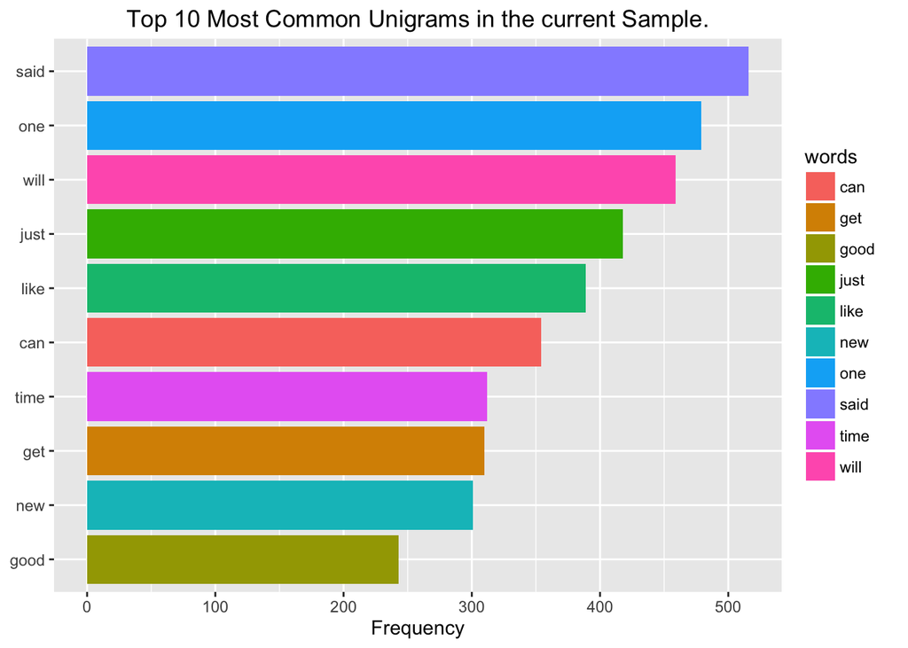

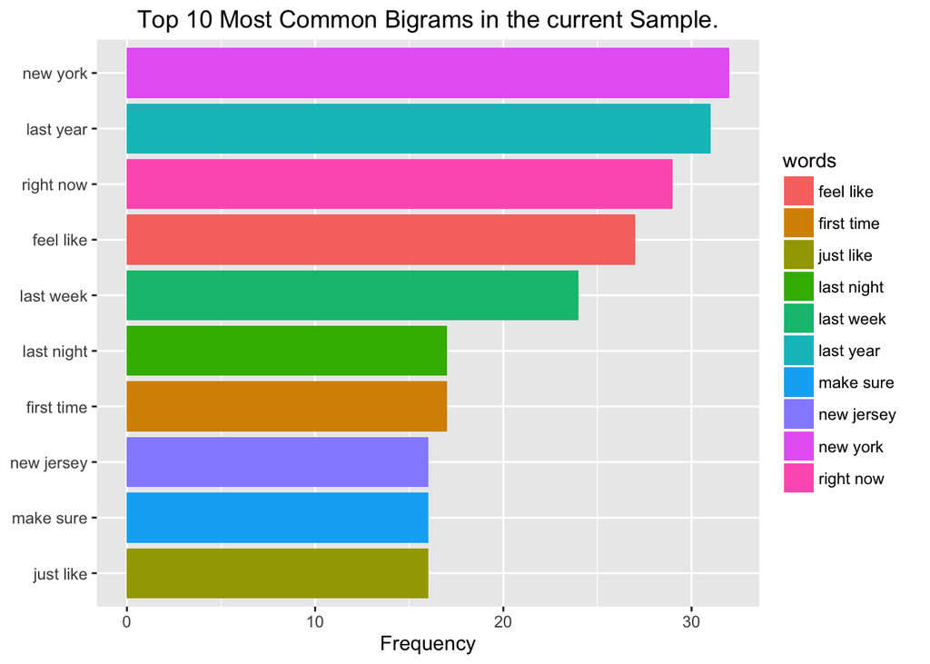

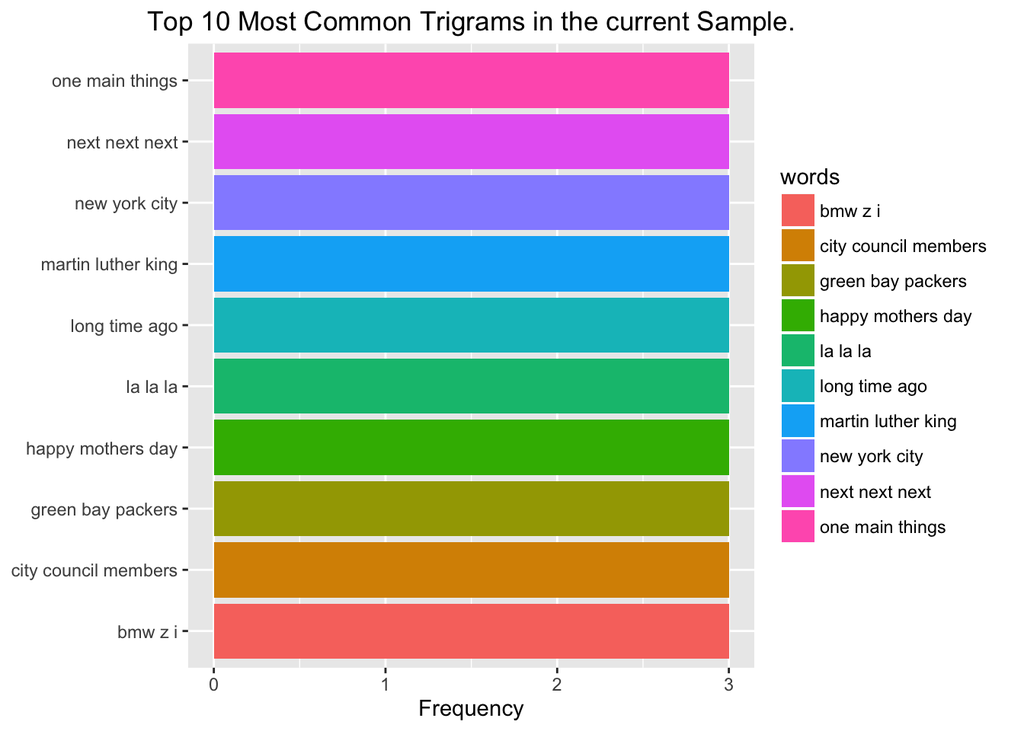

2. What are the frequencies of 2-grams and 3grams in the data set

```r
head(df_biagram, 10)        #top 10
```

```
##         words freq
## 1    new york   32
## 2   last year   31
## 3   right now   29
## 4   feel like   27
## 5   last week   24
## 6  first time   17
## 7  last night   17
## 8   just like   16
## 9   make sure   16
## 10 new jersey   16
```

```r
head(df_triagram, 10)       #top 10
```

```
##                   words freq
## 1               bmw z i    3
## 2  city council members    3
## 3     green bay packers    3
## 4     happy mothers day    3
## 5              la la la    3
## 6         long time ago    3
## 7    martin luther king    3
## 8         new york city    3
## 9        next next next    3
## 10      one main things    3
```

3. How many unique words do you need in a frequency sorted dictionary to cover 50% of all word instances in the language? 90%

```r
quantile(df_unigram$freq, .5)  #50 percent of the observations
```

```
## 50%
##   1
```

```r
quantile(df_unigram$freq, .9)  #90 percent of the observations
```

```
## 90%
##   8
```

## Credit

I used excerpts and learned from the following.  
* *Wikepedia*  
* *quora*  
* *Stanford NLP online course*  
* *Columbia NLP online course*  
* *slideshare.net*  
* *bioconductor*  
* *Stackoverflow*  
* *github*  
* *google*  
* *yahoo*